# HW2_Bravi_Facchiano_Liguori

Group 11

6/7/2023

## Initialization

First, we imported the packages and data.

## Preprocessing

At this point we began with an initial analysis of the data. The first thing we noticed was the fact that different patients seemed to report measurements on different scales. Most of all had values close to zero, while others (for example, patient number 2) showed extremely larger values.

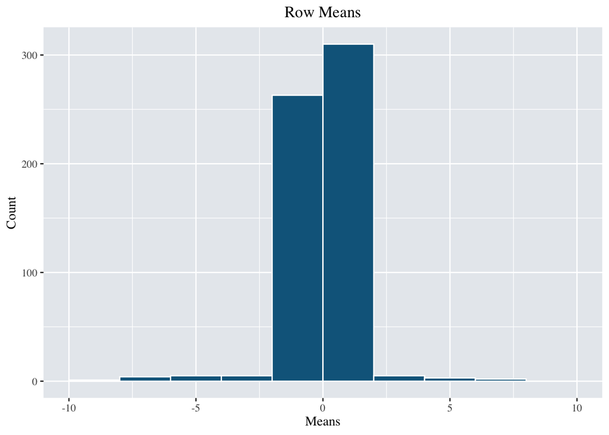

```r
df = data.frame(rowMeans(train[, -c(1:4)]))
ggplot(data = df, aes(x=rowMeans.train....c.1.4...))+
  geom_histogram(breaks=c(-10,-8,-6,-4,-2,0,2,4,6,8,10),fill="#0e668b",color='white')+
  labs(title="Row Means",
       x = "Means",
       y = "Count")+
  theme(text = element_text(family = "serif"),
        plot.title = element_text(hjust=0.5),
        panel.background=element_rect(fill='#e7eaee'))
```

Since our ultimate goal was to construct a classifier capable of distinguishing between the two classes “autism” and “control”, we decided to standardize by row our dataset. This ensured that we had comparable data, and we could proceed with our work.

```r
# We partition our dataset into two chucks. The second chunk contains the quantitative variables that we are going to standardize
train_info <- train[, c(1:4)]
train_roi <- train[, -c(1:4)]

# Scale
train_roi_scale = data.frame(t(apply(train_roi, 1, scale)))
```

Standardization was only our first step toward building a dataset that would allow us to create a suitable classifier.  
Indeed, although a high number of variables is generally a good starting point for building a good model, we cannot forget the danger of *overfitting* that would compromise our results.

We therefore opted for a *dimensionality reduction* in our data.  
The most immediate idea was to use PCA, but we ran into a number of problems. Indeed, not only was it not easy to identify a simple ‘cut-off’ point from the graph of the cumulative variance of the principal components, but it was also not easy to give an interpretation of the variables we were using. And since we had to select the most important variables with specific techniques, this could be quite a problem.

We decided to change our strategy.  
Since the rows of the dataset were many time-series concatenated one after the other, we had chosen to extract some indices for each time-series, and to use them as new features for our model.  
In our opinion, since the rows had been standardized, taking the mean and standard deviation would not have made sense: we therefore opted for more robust and meaningful position indicators, such as quartiles, maximum and minimum.  
These indices were extracted for each historical series, and then put together to create a new reduced dataset.

```r
# Extract the indicators
q1_reduced<- as.data.frame(sapply(seq(1, ncol(train_roi_scale), 115), function(start) {
  end <- start + 115 - 1
  apply(train_roi_scale[, start:end, drop = F], MARGIN = 1, FUN=quantile, probs=0.25)
}))

q2_reduced <- as.data.frame(sapply(seq(1, ncol(train_roi_scale), 115), function(start) {
  end <- start + 115 - 1
  apply(train_roi_scale[, start:end, drop = F], MARGIN = 1, FUN=quantile, probs=0.5)
}))

q3_reduced <- as.data.frame(sapply(seq(1, ncol(train_roi_scale), 115), function(start) {
  end <- start + 115 - 1
  apply(train_roi_scale[, start:end, drop = F], MARGIN = 1, FUN=quantile, probs=0.75)
}))

max_reduced <- as.data.frame(sapply(seq(1, ncol(train_roi_scale), 115), function(start) {
  end <- start + 115 - 1
  apply(train_roi_scale[, start:end, drop = F], MARGIN = 1, FUN=max)
}))

min_reduced <- as.data.frame(sapply(seq(1, ncol(train_roi_scale), 115), function(start) {
  end <- start + 115 - 1
  apply(train_roi_scale[, start:end, drop = F], MARGIN = 1, FUN=min)
}))


# Combine the indicators all together and rename the variables
roi <- unique(
  sub(".*_", "", colnames(train_roi))
)

colnames(q1_reduced) = paste0('q1_', roi)
colnames(q2_reduced) = paste0('q2_', roi)
colnames(q3_reduced) = paste0('q3_', roi)
colnames(max_reduced) = paste0('max_', roi)
colnames(min_reduced) = paste0('min_', roi)

new_data = cbind(train_info, q1_reduced, q2_reduced, q3_reduced, min_reduced, max_reduced)
new_data = new_data[, -1]

new_data$sex = as.factor(ifelse(new_data$sex == 'male', 1, 0))
new_data$y = as.factor(ifelse(new_data$y == 'autism', 1, 0))
```

## The Model: Random Forest for Classification

At this point we were ready to build our model. The choice that seemed most suitable to us was to use a Random Forest. Moreover, despite the reduction in size of the dataset, the number of variables still appeared quite large. Therefore, we chose to use again the caret library.

```r
set.seed(123)

# 1) Control: We opted for a cross-validation as resampling method with 5 folds in order to obtain a good estimate
control <- trainControl(method='cv',
                        number = 5)

# 2) We used the Accuracy as our metric
metric <- "Accuracy"

# 3) We set the parameter mtry as the square root of the number of columns of the training dataset, without counting the response variable.
mtry <- round(sqrt(ncol(new_data) - 1)) # Optimal number of Randomly Selected Predictors for the Random Forest
tunegrid <- expand.grid(.mtry=mtry)

# 4) Fit the model with all the variables and without explicitly tuning the parameters
model1 <- train(y ~. ,
                    data = new_data,
                    method = 'rf',
                    metric = 'Accuracy',
                    tuneGrid = tunegrid,
                    trControl = control)

# 5) Print the output of the model
print(model1)
```

```
## Random Forest
##
## 600 samples
## 582 predictors
##   2 classes: '0', '1'
##
## No pre-processing
## Resampling: Cross-Validated (5 fold)
## Summary of sample sizes: 480, 479, 480, 481, 480
## Resampling results:
##
##   Accuracy  Kappa
##   0.581516  0.1316194
##
## Tuning parameter 'mtry' was held constant at a value of 24
```

Our first model with all the variables doesn’t perform very well. We have an accuracy of 58%, and a Kappa statistic (that is a measure of agreement between the classifications in our model and the actual classes) of 0.13, that is only slightly bigger than the random choice valued as 0.

## Variable Importance

One of the reasons why Random Forest seemed a good idea is that we can easily extract a measure of **Variable Importance** directly from the model, using an index called Mean Decrease Accuracy (MDA). Once this quantity was computed for all variables, we plotted the results. It seemed reasonable to us to focus on the first 50 variables, which offered the right trade-off between model simplicity and good performance.

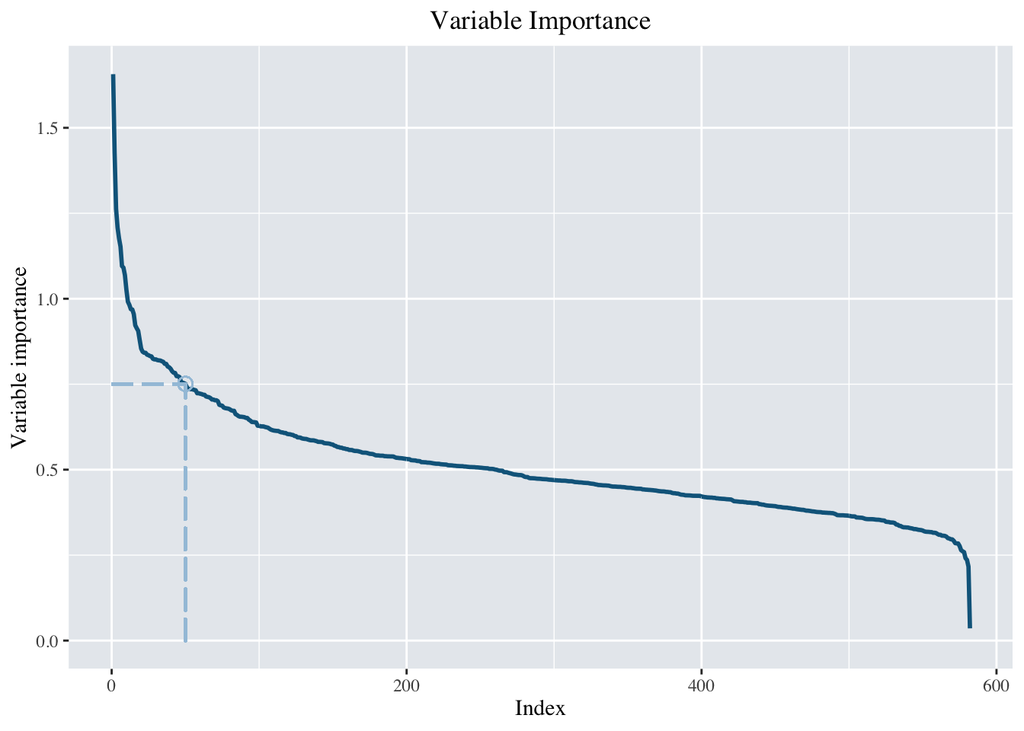

```r
# Extract the variable importance for each feature with the default caret function
var_imp = data.frame(varImp(model1, scale = F)$importance)
var_imp$variable = rownames(var_imp)
var_imp <- data.frame(var_imp[order(var_imp$Overall, decreasing = TRUE), ])

# Plot the results
index = seq(1,582,by=1)
df_var_imp = data.frame(var_imp,index)
ggplot(data = df_var_imp,aes(y=df_var_imp$Overall,x=df_var_imp$index))+
  geom_line(aes(y=df_var_imp$Overall,x=df_var_imp$index),size=1,col="#0e668b")+
  geom_segment(aes(x=50,y=0,yend = 0.7509073,xend=50),size=0.7,linetype=5,col="#a3c4dc",lineend = 'round')+
  geom_segment(aes(x=0,y=0.7509073,yend = 0.7509073,xend=50),size=0.7,linetype=5,col="#a3c4dc")+
  geom_point(aes(x=50,y=0.7509073),col="#a3c4dc",shape=1,size=3)+
  labs(title="Variable Importance",
       x = "Index",
       y = "Variable importance")+
  theme(text = element_text(family = "serif"),
        plot.title = element_text(hjust=0.5),
        panel.background=element_rect(fill='#e7eaee'))
```

```r
# Take the first 50 variables
top_variables = var_imp[1:50, 2]
```

```r
new_data_50 <- new_data[, c(top_variables)]
new_data_50$y <- new_data$y

# This time, to obtain a higher precision for the choice of the best parameter, we decided to use a repeated cross validation
control <- trainControl(method='repeatedcv',
                        number=10,
                        repeats=3,
                        search = 'random')

# We search over 4 different values
tunegrid <- expand.grid(.mtry=c(6, 7, 8, 9))

# We build the second model
model50 <- train(y ~. ,
                      data = new_data_50,
                      method = 'rf',
                      metric = 'Accuracy',
                      tuneGrid = tunegrid,
                      trControl = control)
# Print the result
print(model50)
```

```
## Random Forest
##
## 600 samples
##  50 predictor
##   2 classes: '0', '1'
##
## No pre-processing
## Resampling: Cross-Validated (10 fold, repeated 3 times)
## Summary of sample sizes: 539, 541, 540, 540, 540, 540, ...
## Resampling results across tuning parameters:
##
##   mtry  Accuracy   Kappa
##   6     0.6689574  0.3253665
##   7     0.6639195  0.3157407
##   8     0.6622170  0.3125142
##   9     0.6749972  0.3381920
##
## Accuracy was used to select the optimal model using the largest value.
## The final value used for the model was mtry = 9.
```

## LOCO: an alternative view on Variable Importance

**LOCO** Inference is a procedure developed by Lei et al. (2016), which is proposed as an alternative measure of variable importance.  
This procedure consists in estimating a function $\hat{f}_{n_1}$ over the entire training dataset, and comparing an arbitrary loss of it (in our case we chose to use the *F1 score*) with the one of a function $\hat{f}_{n_1}^{-j}$, obtained by removing one variable j at a time from the dataset.

To reduce computational costs, we have selected only the top variables by their importance. To avoid biases in the results, we then checked the presence of highly correlated variables before evaluating the LOCO scores, and we discarded the variables that show a very high correlation. In fact, citing the book [Limitations of Interpretable Machine Learning Methods](https://slds-lmu.github.io/iml_methods_limitations/pfi-correlated.html), «If you leave out one feature that is perfectly correlated to the other, the performance will be the same as before. Since the feature which is still in the data set contains exactly the same information as the one left out there is no alteration in performance».

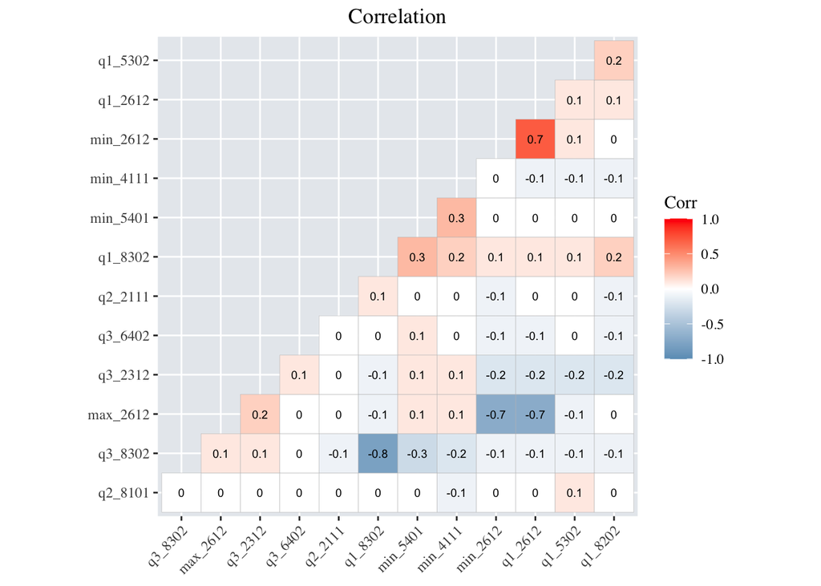

We are now ready to compute the LOCO scores.

```r
# STEP 1: partition in train and test
idx <- createDataPartition(LOCO_variables$y, p = 0.8, list = FALSE)
new_data_10_train <- LOCO_variables[-idx,] # 80%
new_data_10_test <- LOCO_variables[idx,] # 20%

# STEP 2: Run algorithm to compute estimate f_hat on D1
mtry <- round(sqrt(ncol(new_data_10_train) - 1))
tunegrid <- expand.grid(.mtry=mtry)
control <- trainControl(method='cv',
                        number = 5)

model10 <- train(y ~. ,
                    data = new_data_10_train,
                    method = 'rf',
                    metric = 'Accuracy',
                    tuneGrid = tunegrid,
                    trControl = control)
f_hat <- factor(predict(model10, newdata = new_data_10_train))
y_true <- factor(new_data_10_train$y)
F1 = confusionMatrix(f_hat, y_true, mode = "everything", positive="1")$byClass[7]


# STEP 3: we use the test to obtain M bootstrap samples, and for each sample we predict and evaluate the F1 score. We compare F1_j (that is the F1 score computed without the j-th variable) with the baseline F1 score for each of the M samples, and we finally take the median.
LOCO_scores <- list()
LOCO_punctual <- c()
M <- 100

for(j in 1:(ncol(LOCO_variables)-1)){
  model_j <- train(y ~. ,
                data = new_data_10_train[, -j],
                method = 'rf',
                metric = 'Accuracy',
                tuneGrid = tunegrid,
                trControl = control)
  vec <- c()

  for(m in 1:M){
    idx_boot <- sample(1:119, size = 119, replace = T)
    sample_boot <- new_data_10_test[idx_boot, ]

    f_hat_j <- factor(predict(model_j, newdata = sample_boot))
    y_true <- factor(sample_boot$y)

    F1_j = confusionMatrix(f_hat_j, y_true, mode = "everything", positive="1")$byClass[7]

    vec <- c(vec, F1_j)
  }

  LOCO_scores[[j]] <- c(mean(F1-vec) - 2*sd(F1-vec), mean(F1-vec) + 2*sd(F1-vec))
  LOCO_punctual <- c(LOCO_punctual, median(F1-vec))

}
```

We can also plot the LOCO scores:

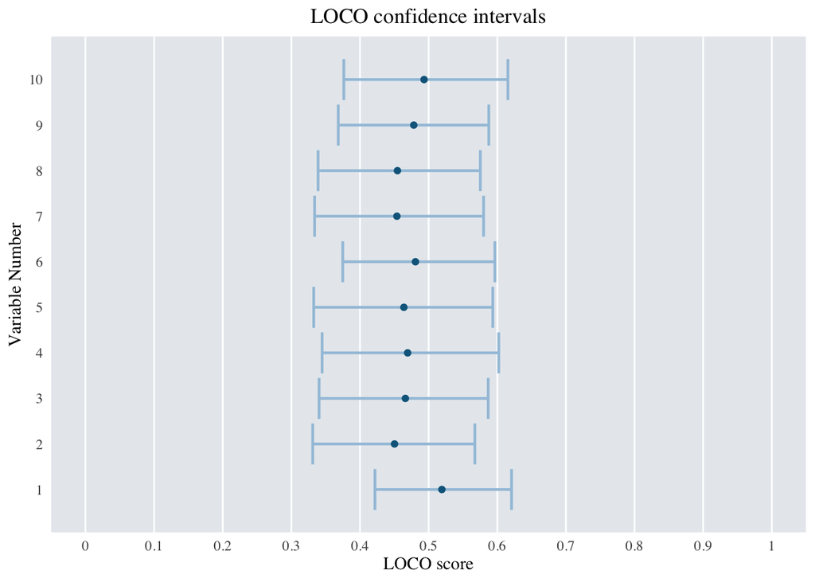

## Predictions

We are finally ready to make predictions on our test set.  
We therefore import the dataset, reduce the dimensionality by exracting the quartiles and the maximum and minimum for each time series and finally fit the model.

```r
test <- read_csv("/Users/simonefacchiano/Desktop/Data Science/SL/Homework 2/test_hw03.csv")
test_info <- test[, c(1:3)]
test_roi <- test[, -c(1:3)]

# Scale
test_roi_scale = data.frame(t(apply(test_roi, 1, scale)))

# Dimensionality reduction
q1_reduced_test <- as.data.frame(sapply(seq(1, ncol(test_roi_scale), 115), function(start) {
  end <- start + 115 - 1
  apply(test_roi_scale[, start:end, drop = F], MARGIN = 1, FUN=quantile, probs=0.25)
}))

q2_reduced_test <- as.data.frame(sapply(seq(1, ncol(test_roi_scale), 115), function(start) {
  end <- start + 115 - 1
  apply(test_roi_scale[, start:end, drop = F], MARGIN = 1, FUN=quantile, probs=0.5)
}))

q3_reduced_test <- as.data.frame(sapply(seq(1, ncol(test_roi_scale), 115), function(start) {
  end <- start + 115 - 1
  apply(test_roi_scale[, start:end, drop = F], MARGIN = 1, FUN=quantile, probs=0.75)
}))

max_reduced_test <- as.data.frame(sapply(seq(1, ncol(test_roi_scale), 115), function(start) {
  end <- start + 115 - 1
  apply(test_roi_scale[, start:end, drop = F], MARGIN = 1, FUN=max)
}))

min_reduced_test <- as.data.frame(sapply(seq(1, ncol(test_roi_scale), 115), function(start) {
  end <- start + 115 - 1
  apply(test_roi_scale[, start:end, drop = F], MARGIN = 1, FUN=min)
}))


# Rename the variables
colnames(q1_reduced_test) = paste0('q1_', roi)
colnames(q2_reduced_test) = paste0('q2_', roi)
colnames(q3_reduced_test) = paste0('q3_', roi)
colnames(max_reduced_test) = paste0('max_', roi)
colnames(min_reduced_test) = paste0('min_', roi)

# Concatenate the variables
new_data_test = cbind(test_info, q1_reduced_test, q2_reduced_test, q3_reduced_test, min_reduced_test, max_reduced_test)
new_data_test = new_data_test[, -1]

new_data_test$sex = as.factor(ifelse(new_data_test$sex == 'male', 1, 0))

new_data_10_test <- new_data_test[, colnames(new_data_50)[1:50]]
```

We can finally make the predictions and save the output in a .csv file, that we can submit in Kaggle.

```r
id <- test$id
target = predict(model50, newdata = new_data_10_test)
target = ifelse(target == 1, 'autism', 'control')

preds_g11 = data.frame('id' = id, 'target' = target)

write.csv(preds_g11, file = "/Users/simonefacchiano/Desktop/Data Science/SL/Homework 2/preds_g11.csv", row.names = FALSE)
```